# Practical Machine Learning

Final Project

Fabio Paderi

17/1/2018

### Background

Using devices such as Jawbone Up, Nike FuelBand, and Fitbit it is now possible to collect a large amount of data about personal activity relatively inexpensively. These type of devices are part of the quantified self movement – a group of enthusiasts who take measurements about themselves regularly to improve their health, to find patterns in their behavior, or because they are tech geeks. One thing that people regularly do is quantify how much of a particular activity they do, but they rarely quantify how well they do it. In this project, your goal will be to use data from accelerometers on the belt, forearm, arm, and dumbell of 6 participants. They were asked to perform barbell lifts correctly and incorrectly in 5 different ways. More information is available from the website [here](http://web.archive.org/web/20161224072740/http:/groupware.les.inf.puc-rio.br/har) (see the section on the Weight Lifting Exercise Dataset).

```
      The goal of this project is to predict the manner in which six participants did their exercise.
```

### Load Data

We are going to load only the training set, we leave test set as a Validation set in final phase

```r
training <- read.csv("pml-training.csv", header = TRUE, na.strings=c("NA","#DIV/0!",""))
```

### Preparing Data

```r
## First we define a function to compute the proportion of missing data for each
## variable, then we delete variables with more than 60% missing data

percent_miss <- function(x) {
      sum(is.na(x))/length(x)
}

too.miss <- as.numeric(apply(training, 2, percent_miss) > 0.6)
training <- training[, too.miss == 0]

nZeroVar <- nearZeroVar(training, saveMetrics = TRUE)
training <- training[, nZeroVar$nzv == FALSE]

## removing other not useful variables
training$X <- NULL
training$cvtd_timestamp <- NULL


## defining a training and a test set
index <- rbinom(dim(training)[1], 1, p = 0.7)

training <- training[index == 1,]
testing <- training[index == 0, ]

## removing missing values from the outcome in the test set
testing <- testing %>%
      filter(!is.na(classe))
```

#### Decision tree

```r
library(rpart)

mod1 <- rpart(classe ~., data = training,
              method = "class", control = rpart.control(cp = 0.0001))

p1 <- predict(mod1, testing, type = "class")
confusionMatrix(p1, testing$classe)
```

```
Confusion Matrix and Statistics

          Reference
Prediction    A    B    C    D    E
         A 1187    4    1    0    0
         B    3  784    6    6    0
         C    0    8  697    4    0
         D    2    3    2  678    2
         E    0    3    2    4  757

Overall Statistics

               Accuracy : 0.988
                 95% CI : (0.9842, 0.9911)
    No Information Rate : 0.287
    P-Value [Acc > NIR] : < 2.2e-16

                  Kappa : 0.9848
 Mcnemar's Test P-Value : NA

Statistics by Class:

                     Class: A Class: B Class: C Class: D Class: E
Sensitivity            0.9958   0.9776   0.9845   0.9798   0.9974
Specificity            0.9983   0.9955   0.9965   0.9974   0.9973
Pos Pred Value         0.9958   0.9812   0.9831   0.9869   0.9883
Neg Pred Value         0.9983   0.9946   0.9968   0.9960   0.9994
Prevalence             0.2870   0.1931   0.1705   0.1666   0.1828
Detection Rate         0.2858   0.1888   0.1678   0.1633   0.1823
Detection Prevalence   0.2870   0.1924   0.1707   0.1654   0.1844
Balanced Accuracy      0.9971   0.9865   0.9905   0.9886   0.9974
```

#### Support Vector Machine

```r
library(e1071)

mod2 <- svm(classe ~., data = training, scale = TRUE)
p2 <- predict(mod2, testing, type = "class")

confusionMatrix(p2, testing$classe)
```

```
Confusion Matrix and Statistics

          Reference
Prediction    A    B    C    D    E
         A 1180   38    1    0    0
         B    3  748   19    0    0
         C    9   16  685   67   12
         D    0    0    3  625   13
         E    0    0    0    0  734

Overall Statistics

               Accuracy : 0.9564
                 95% CI : (0.9498, 0.9624)
    No Information Rate : 0.287
    P-Value [Acc > NIR] : < 2.2e-16

                  Kappa : 0.9448
 Mcnemar's Test P-Value : NA

Statistics by Class:

                     Class: A Class: B Class: C Class: D Class: E
Sensitivity            0.9899   0.9327   0.9675   0.9032   0.9671
Specificity            0.9868   0.9934   0.9698   0.9954   1.0000
Pos Pred Value         0.9680   0.9714   0.8682   0.9750   1.0000
Neg Pred Value         0.9959   0.9840   0.9932   0.9809   0.9927
Prevalence             0.2870   0.1931   0.1705   0.1666   0.1828
Detection Rate         0.2841   0.1801   0.1649   0.1505   0.1767
Detection Prevalence   0.2935   0.1854   0.1900   0.1543   0.1767
Balanced Accuracy      0.9884   0.9631   0.9687   0.9493   0.9835
```

#### Random Forest

```r
library(randomForest)

mod3 <- randomForest(classe ~., data = training, ntree = 200, mtry = 4)

p3 <- predict(mod3, testing)

confusionMatrix(p3, testing$classe)
```

```
Confusion Matrix and Statistics

          Reference
Prediction    A    B    C    D    E
         A 1192    0    0    0    0
         B    0  802    0    0    0
         C    0    0  708    0    0
         D    0    0    0  692    0
         E    0    0    0    0  759

Overall Statistics

               Accuracy : 1
                 95% CI : (0.9991, 1)
    No Information Rate : 0.287
    P-Value [Acc > NIR] : < 2.2e-16

                  Kappa : 1
 Mcnemar's Test P-Value : NA

Statistics by Class:

                     Class: A Class: B Class: C Class: D Class: E
Sensitivity             1.000   1.0000   1.0000   1.0000   1.0000
Specificity             1.000   1.0000   1.0000   1.0000   1.0000
Pos Pred Value          1.000   1.0000   1.0000   1.0000   1.0000
Neg Pred Value          1.000   1.0000   1.0000   1.0000   1.0000
Prevalence              0.287   0.1931   0.1705   0.1666   0.1828
Detection Rate          0.287   0.1931   0.1705   0.1666   0.1828
Detection Prevalence    0.287   0.1931   0.1705   0.1666   0.1828
Balanced Accuracy       1.000   1.0000   1.0000   1.0000   1.0000
```

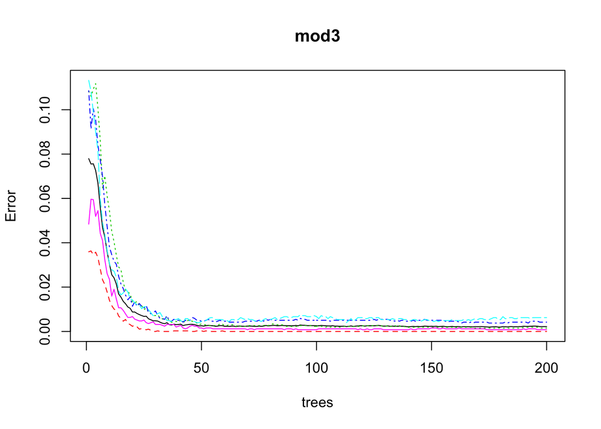

```r
plot(mod3)
```

As we have found an algorithm which has an accuracy of 1, we decide to retain it and to apply to the validation set.

Our final prediction for the 20 test samples are the following:

```r
validation <- read.csv("pml-testing.csv", header = TRUE,
                       na.strings=c("NA","#DIV/0!",""))

knitr::kable(t(predict(mod3, validation)))
```

| 1 | 2 | 3 | 4 | 5 | 6 | 7 | 8 | 9 | 10 | 11 | 12 | 13 | 14 | 15 | 16 | 17 | 18 | 19 | 20 |
| --- | --- | --- | --- | --- | --- | --- | --- | --- | --- | --- | --- | --- | --- | --- | --- | --- | --- | --- | --- |
| B | A | B | A | A | E | D | B | A | A | B | C | B | A | E | E | A | B | B | B |